# LendingClub Loan Default Prediction, Deep Learning

## The Data

We will be using a subset of the LendingClub DataSet obtained from Kaggle: https://www.kaggle.com/wordsforthewise/lending-club

LendingClub is a US peer-to-peer lending company, headquartered in San Francisco, California.[3] It was the first peer-to-peer lender to register its offerings as securities with the Securities and Exchange Commission (SEC), and to offer loan trading on a secondary market. LendingClub is the world's largest peer-to-peer lending platform.

## Goal

Given historical data on loans given out with information on whether or not the borrower defaulted (charge-off), can we build a model thatcan predict wether or nor a borrower will pay back their loan? This way in the future when we get a new potential customer we can assess whether or not they are likely to pay back the loan. Keep in mind classification metrics when evaluating the performance of your model!

The "loan_status" column contains our label.

## Data Overview

There are many LendingClub data sets on Kaggle. Here is the information on this particular data set:

|  | LoanStatNew | Description |
| --- | --- | --- |
| 0 | loan_amnt | The listed amount of the loan applied for by the borrower. If at some point in time, the credit department reduces the loan amount, then it will be reflected in this value. |
| 1 | term | The number of payments on the loan. Values are in months and can be either 36 or 60. |
| 2 | int_rate | Interest Rate on the loan |
| 3 | installment | The monthly payment owed by the borrower if the loan originates. |
| 4 | grade | LC assigned loan grade |
| 5 | sub_grade | LC assigned loan subgrade |
| 6 | emp_title | The job title supplied by the Borrower when applying for the loan.* |
| 7 | emp_length | Employment length in years. Possible values are between 0 and 10 where 0 means less than one year and 10 means ten or more years. |
| 8 | home_ownership | The home ownership status provided by the borrower during registration or obtained from the credit report. Our values are: RENT, OWN, MORTGAGE, OTHER |
| 9 | annual_inc | The self-reported annual income provided by the borrower during registration. |
| 10 | verification_status | Indicates if income was verified by LC, not verified, or if the income source was verified |
| 11 | issue_d | The month which the loan was funded |
| 12 | loan_status | Current status of the loan |
| 13 | purpose | A category provided by the borrower for the loan request. |
| 14 | title | The loan title provided by the borrower |
| 15 | zip_code | The first 3 numbers of the zip code provided by the borrower in the loan application. |
| 16 | addr_state | The state provided by the borrower in the loan application |
| 17 | dti | A ratio calculated using the borrower’s total monthly debt payments on the total debt obligations, excluding mortgage and the requested LC loan, divided by the borrower’s self-reported monthly income. |
| 18 | earliest_cr_line | The month the borrower's earliest reported credit line was opened |
| 19 | open_acc | The number of open credit lines in the borrower's credit file. |
| 20 | pub_rec | Number of derogatory public records |
| 21 | revol_bal | Total credit revolving balance |
| 22 | revol_util | Revolving line utilization rate, or the amount of credit the borrower is using relative to all available revolving credit. |
| 23 | total_acc | The total number of credit lines currently in the borrower's credit file |
| 24 | initial_list_status | The initial listing status of the loan. Possible values are – W, F |
| 25 | application_type | Indicates whether the loan is an individual application or a joint application with two co-borrowers |
| 26 | mort_acc | Number of mortgage accounts. |
| 27 | pub_rec_bankruptcies | Number of public record bankruptcies |

## Preparation

```python
import pandas as pd
import numpy as np
import matplotlib.pyplot as plt
import seaborn as sns
%matplotlib inline
```

```python
data_info = pd.read_csv('../DATA/lending_club_info.csv',index_col='LoanStatNew')
```

```python
print(data_info.loc['revol_util']['Description'])
```

```
Revolving line utilization rate, or the amount of credit the borrower is using relative to all available revolving credit.
```

```python
def feat_info(col_name):
    print(data_info.loc[col_name]['Description'])
```

```python
feat_info('mort_acc')
```

```
Number of mortgage accounts.
```

```python
df = pd.read_csv('../DATA/lending_club_loan_two.csv')
```

```python
df.info()
```

```
<class 'pandas.core.frame.DataFrame'>
RangeIndex: 396030 entries, 0 to 396029
Data columns (total 27 columns):
 #   Column                Non-Null Count   Dtype
---  ------                --------------   -----
 0   loan_amnt             396030 non-null  float64
 1   term                  396030 non-null  object
 2   int_rate              396030 non-null  float64
 3   installment           396030 non-null  float64
 4   grade                 396030 non-null  object
 5   sub_grade             396030 non-null  object
 6   emp_title             373103 non-null  object
 7   emp_length            377729 non-null  object
 8   home_ownership        396030 non-null  object
 9   annual_inc            396030 non-null  float64
```

[output cut: 19 more lines]

## Section 1: Exploratory Data Analysis

**Section Goal: Get an understanding for which variables are important, view summary statistics, and visualize the data**

**Countplot of loan_status**

```python
sns.set_palette('dark')
sns.set_style('whitegrid')
```

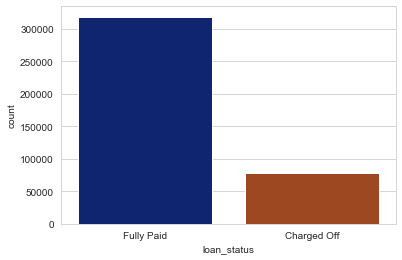

```python
sns.countplot(data=df, x='loan_status')
```

**Histogram of the loan_amnt column.**

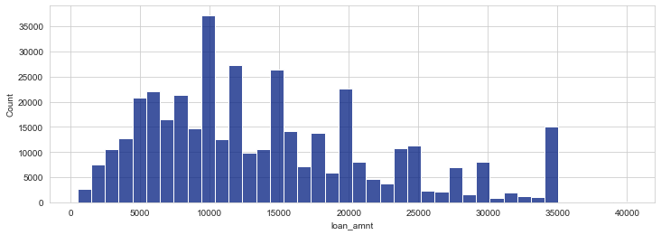

```python
plt.figure(figsize=(12,4))
sns.histplot(data=df,x='loan_amnt',bins=40)
```

**Explore correlation between the continuous feature variables.**

```python
df.corr()
```

|  | loan_amnt | int_rate | installment | annual_inc | dti | open_acc | pub_rec | revol_bal | revol_util | total_acc | mort_acc | pub_rec_bankruptcies |
| --- | --- | --- | --- | --- | --- | --- | --- | --- | --- | --- | --- | --- |
| loan_amnt | 1.000000 | 0.168921 | 0.953929 | 0.336887 | 0.016636 | 0.198556 | -0.077779 | 0.328320 | 0.099911 | 0.223886 | 0.222315 | -0.106539 |
| int_rate | 0.168921 | 1.000000 | 0.162758 | -0.056771 | 0.079038 | 0.011649 | 0.060986 | -0.011280 | 0.293659 | -0.036404 | -0.082583 | 0.057450 |
| installment | 0.953929 | 0.162758 | 1.000000 | 0.330381 | 0.015786 | 0.188973 | -0.067892 | 0.316455 | 0.123915 | 0.202430 | 0.193694 | -0.098628 |
| annual_inc | 0.336887 | -0.056771 | 0.330381 | 1.000000 | -0.081685 | 0.136150 | -0.013720 | 0.299773 | 0.027871 | 0.193023 | 0.236320 | -0.050162 |
| dti | 0.016636 | 0.079038 | 0.015786 | -0.081685 | 1.000000 | 0.136181 | -0.017639 | 0.063571 | 0.088375 | 0.102128 | -0.025439 | -0.014558 |
| open_acc | 0.198556 | 0.011649 | 0.188973 | 0.136150 | 0.136181 | 1.000000 | -0.018392 | 0.221192 | -0.131420 | 0.680728 | 0.109205 | -0.027732 |
| pub_rec | -0.077779 | 0.060986 | -0.067892 | -0.013720 | -0.017639 | -0.018392 | 1.000000 | -0.101664 | -0.075910 | 0.019723 | 0.011552 | 0.699408 |
| revol_bal | 0.328320 | -0.011280 | 0.316455 | 0.299773 | 0.063571 | 0.221192 | -0.101664 | 1.000000 | 0.226346 | 0.191616 | 0.194925 | -0.124532 |
| revol_util | 0.099911 | 0.293659 | 0.123915 | 0.027871 | 0.088375 | -0.131420 | -0.075910 | 0.226346 | 1.000000 | -0.104273 | 0.007514 | -0.086751 |
| total_acc | 0.223886 | -0.036404 | 0.202430 | 0.193023 | 0.102128 | 0.680728 | 0.019723 | 0.191616 | -0.104273 | 1.000000 | 0.381072 | 0.042035 |
| mort_acc | 0.222315 | -0.082583 | 0.193694 | 0.236320 | -0.025439 | 0.109205 | 0.011552 | 0.194925 | 0.007514 | 0.381072 | 1.000000 | 0.027239 |
| pub_rec_bankruptcies | -0.106539 | 0.057450 | -0.098628 | -0.050162 | -0.014558 | -0.027732 | 0.699408 | -0.124532 | -0.086751 | 0.042035 | 0.027239 | 1.000000 |

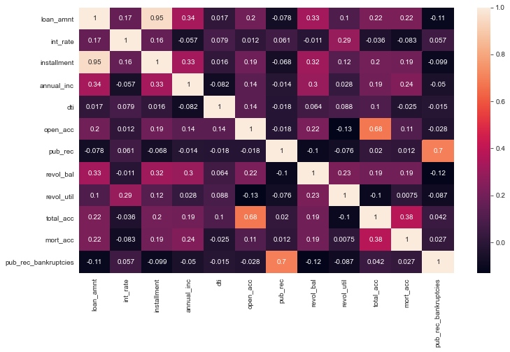

```python
plt.figure(figsize=(12,7))
sns.heatmap(df.corr(), annot=True)
```

**Noticed almost perfect correlation with the "installment" feature. Explore this feature further.**

```python
feat_info('installment')
```

```
The monthly payment owed by the borrower if the loan originates.
```

```python
feat_info('loan_amnt')
```

```
The listed amount of the loan applied for by the borrower. If at some point in time, the credit department reduces the loan amount, then it will be reflected in this value.
```

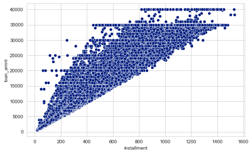

```python
plt.figure(figsize=(8,5))
sns.scatterplot(x='installment', y='loan_amnt', data=df)
```

**Explore loan_status and the Loan Amount.**

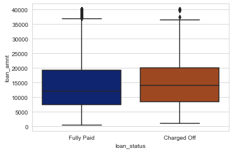

```python
sns.boxplot(x='loan_status', y='loan_amnt', data=df)
```

```python
df.groupby('loan_status')['loan_amnt'].describe().transpose()
```

| loan_status | Charged Off | Fully Paid |
| --- | --- | --- |
| count | 77673.000000 | 318357.000000 |
| mean | 15126.300967 | 13866.878771 |
| std | 8505.090557 | 8302.319699 |
| min | 1000.000000 | 500.000000 |
| 25% | 8525.000000 | 7500.000000 |
| 50% | 14000.000000 | 12000.000000 |
| 75% | 20000.000000 | 19225.000000 |
| max | 40000.000000 | 40000.000000 |

**Explore the Grade and SubGrade columns that LendingClub attributes to the loans.**

```python
sorted(df['grade'].unique())
```

```
['A', 'B', 'C', 'D', 'E', 'F', 'G']
```

```python
sorted(df['sub_grade'].unique())
```

```
['A1',
 'A2',
 'A3',
 'A4',
 'A5',
 'B1',
 'B2',
 'B3',
 'B4',
 'B5',
 'C1',
 'C2',
 'C3',
 'C4',
 'C5',
 'D1',
 'D2',
 'D3',
 'D4',
 'D5',
 'E1',
 'E2',
 'E3',
 'E4',
 'E5',
 'F1',
 'F2',
 'F3',
 'F4',
 'F5',
 'G1',
 'G2',
 'G3',
 'G4',
 'G5']
```

**Countplot per grade.**

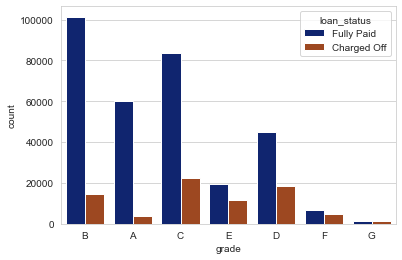

```python
sns.countplot(x='grade', data=df, hue='loan_status')
```

**Countplot per subgrade.**

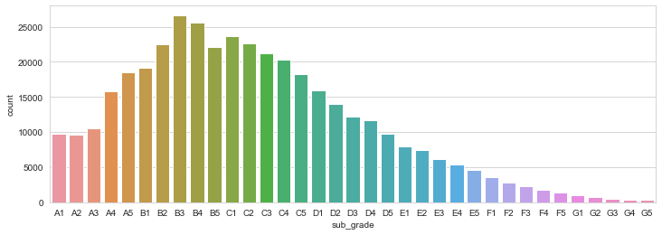

```python
plt.figure(figsize=(12,4))
sub_order = sorted(df['sub_grade'].unique())
sns.countplot(x='sub_grade', data=df, order = sub_order)
```

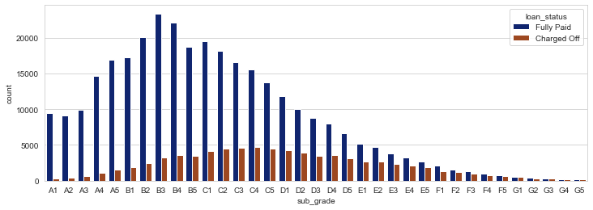

```python
plt.figure(figsize=(12,4))
sub_order = sorted(df['sub_grade'].unique())
sns.countplot(x='sub_grade', data=df, order = sub_order, hue='loan_status')
```

**Isloate F and G subgrades as they don't get paid back often**

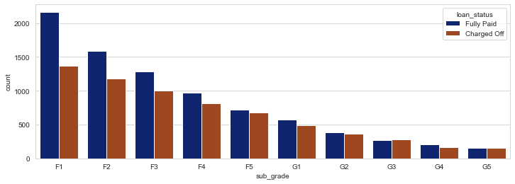

```python
plt.figure(figsize=(12,4))
f_g=df[(df['grade']=='G')|(df['grade']=='F')]
sub_order = sorted(f_g['sub_grade'].unique())
sns.countplot(x='sub_grade', data=f_g, order = sub_order, hue='loan_status')
```

**Map loan_status to 1 and 0**

```python
df['loan_status'].unique()
```

```
array(['Fully Paid', 'Charged Off'], dtype=object)
```

```python
df['loan_repaid']=df['loan_status'].map({'Fully Paid':1,'Charged Off':0})
```

```python
df[['loan_repaid', 'loan_status']]
```

|  | loan_repaid | loan_status |
| --- | --- | --- |
| 0 | 1 | Fully Paid |
| 1 | 1 | Fully Paid |
| 2 | 1 | Fully Paid |
| 3 | 1 | Fully Paid |
| 4 | 0 | Charged Off |
| ... | ... | ... |
| 396025 | 1 | Fully Paid |
| 396026 | 1 | Fully Paid |
| 396027 | 1 | Fully Paid |
| 396028 | 1 | Fully Paid |
| 396029 | 1 | Fully Paid |

396030 rows × 2 columns

**Show the correlation of the numeric features to the loan_repaid.**

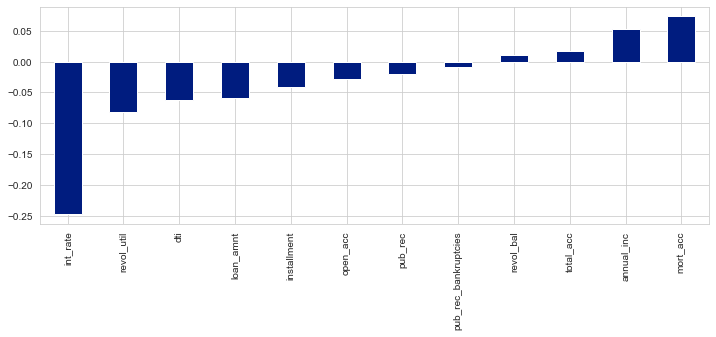

```python
plt.figure(figsize=(12,4))
df.corr()['loan_repaid'].drop('loan_repaid').sort_values().plot(kind='bar')
```

## Section 2: Data PreProcessing

**Section Goals: Remove or fill any missing data. Remove unnecessary or repetitive features. Convert categorical string features to dummy variables.**

```python
df.head()
```

|  | loan_amnt | term | int_rate | installment | grade | sub_grade | emp_title | emp_length | home_ownership | annual_inc | ... | pub_rec | revol_bal | revol_util | total_acc | initial_list_status | application_type | mort_acc | pub_rec_bankruptcies | address | loan_repaid |
| --- | --- | --- | --- | --- | --- | --- | --- | --- | --- | --- | --- | --- | --- | --- | --- | --- | --- | --- | --- | --- | --- |
| 0 | 10000.0 | 36 months | 11.44 | 329.48 | B | B4 | Marketing | 10+ years | RENT | 117000.0 | ... | 0.0 | 36369.0 | 41.8 | 25.0 | w | INDIVIDUAL | 0.0 | 0.0 | 0174 Michelle Gateway\nMendozaberg, OK 22690 | 1 |
| 1 | 8000.0 | 36 months | 11.99 | 265.68 | B | B5 | Credit analyst | 4 years | MORTGAGE | 65000.0 | ... | 0.0 | 20131.0 | 53.3 | 27.0 | f | INDIVIDUAL | 3.0 | 0.0 | 1076 Carney Fort Apt. 347\nLoganmouth, SD 05113 | 1 |
| 2 | 15600.0 | 36 months | 10.49 | 506.97 | B | B3 | Statistician | < 1 year | RENT | 43057.0 | ... | 0.0 | 11987.0 | 92.2 | 26.0 | f | INDIVIDUAL | 0.0 | 0.0 | 87025 Mark Dale Apt. 269\nNew Sabrina, WV 05113 | 1 |
| 3 | 7200.0 | 36 months | 6.49 | 220.65 | A | A2 | Client Advocate | 6 years | RENT | 54000.0 | ... | 0.0 | 5472.0 | 21.5 | 13.0 | f | INDIVIDUAL | 0.0 | 0.0 | 823 Reid Ford\nDelacruzside, MA 00813 | 1 |
| 4 | 24375.0 | 60 months | 17.27 | 609.33 | C | C5 | Destiny Management Inc. | 9 years | MORTGAGE | 55000.0 | ... | 0.0 | 24584.0 | 69.8 | 43.0 | f | INDIVIDUAL | 1.0 | 0.0 | 679 Luna Roads\nGreggshire, VA 11650 | 0 |

5 rows × 28 columns

### Missing Data

**See if we should keep, discard, or fill in the missing data.**

**Length of the dataframe**

```python
len(df)
```

```
396030
```

**Displays the total count of missing values per column.**

```python
df.isnull().sum()
```

```
loan_amnt                   0
term                        0
int_rate                    0
installment                 0
grade                       0
sub_grade                   0
emp_title               22927
emp_length              18301
home_ownership              0
annual_inc                  0
verification_status         0
issue_d                     0
loan_status                 0
purpose                     0
title                    1755
dti                         0
earliest_cr_line            0
open_acc                    0
pub_rec                     0
revol_bal                   0
revol_util                276
total_acc                   0
initial_list_status         0
application_type            0
mort_acc                37795
pub_rec_bankruptcies      535
address                     0
loan_repaid                 0
dtype: int64
```

**Percentage of missing data**

```python
df.isnull().sum()/len(df)* 100
```

```
loan_amnt               0.000000
term                    0.000000
int_rate                0.000000
installment             0.000000
grade                   0.000000
sub_grade               0.000000
emp_title               5.789208
emp_length              4.621115
home_ownership          0.000000
annual_inc              0.000000
verification_status     0.000000
issue_d                 0.000000
loan_status             0.000000
purpose                 0.000000
title                   0.443148
dti                     0.000000
earliest_cr_line        0.000000
open_acc                0.000000
pub_rec                 0.000000
revol_bal               0.000000
revol_util              0.069692
total_acc               0.000000
initial_list_status     0.000000
application_type        0.000000
mort_acc                9.543469
pub_rec_bankruptcies    0.135091
address                 0.000000
loan_repaid             0.000000
dtype: float64
```

**Check if we can drop emp_title and emp_length**

```python
feat_info('emp_title')
print('\n')
feat_info('emp_length')
```

```
The job title supplied by the Borrower when applying for the loan.*


Employment length in years. Possible values are between 0 and 10 where 0 means less than one year and 10 means ten or more years.
```

**Unique employment job titles**

```python
df['emp_title'].nunique()
```

```
173105
```

```python
df['emp_title'].value_counts()
```

```
Teacher                            4389
Manager                            4250
Registered Nurse                   1856
RN                                 1846
Supervisor                         1830
                                   ...
Relationships Banker                  1
fremont unified school district       1
Cook lll                              1
Hayward Labrotories                   1
IMT RESIDENTIAL                       1
Name: emp_title, Length: 173105, dtype: int64
```

**Too many unique title to contert to dummy variable. Drop**

```python
df=df.drop('emp_title', axis=1)
```

**Countplot of the emp_length.**

```python
sorted(df['emp_length'].dropna().unique())
```

```
['1 year',
 '10+ years',
 '2 years',
 '3 years',
 '4 years',
 '5 years',
 '6 years',
 '7 years',
 '8 years',
 '9 years',
 '< 1 year']
```

```python
order_l=['< 1 year',
'1 year',
 '2 years',
 '3 years',
 '4 years',
 '5 years',
 '6 years',
 '7 years',
 '8 years',
 '9 years',
 '10+ years']
```

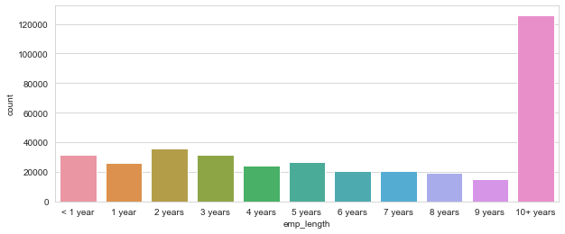

```python
plt.figure(figsize=(10,4))
sns.countplot(data=df, x= 'emp_length', order=order_l)
```

**Separate countplot with loan_status**

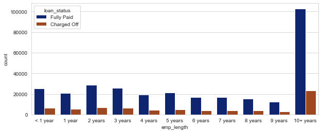

```python
plt.figure(figsize=(10,4))
sns.countplot(data=df, x= 'emp_length', order=order_l, hue='loan_status')
```

**Percentage of charge offs per category.**

```python
emp_co=df[df['loan_status']=='Charged Off'].groupby('emp_length').count()['loan_status']
```

```python
emp_fp = df[df['loan_status']=='Fully Paid'].groupby('emp_length').count()['loan_status']
```

```python
emp_ratio=emp_co/emp_fp
emp_ratio
```

```
emp_length
1 year       0.248649
10+ years    0.225770
2 years      0.239560
3 years      0.242593
4 years      0.238213
5 years      0.237911
6 years      0.233341
7 years      0.241887
8 years      0.249625
9 years      0.250735
< 1 year     0.260830
Name: loan_status, dtype: float64
```

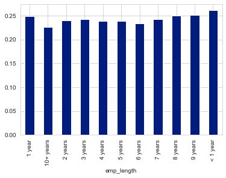

```python
emp_ratio.plot(kind='bar')
```

**Default percentage are extremely similar across all employment lengths. DROP**

```python
df=df.drop('emp_length', axis=1)
```

**Revisit missing data.**

```python
df.isnull().sum()
```

```
loan_amnt                   0
term                        0
int_rate                    0
installment                 0
grade                       0
sub_grade                   0
home_ownership              0
annual_inc                  0
verification_status         0
issue_d                     0
loan_status                 0
purpose                     0
title                    1755
dti                         0
earliest_cr_line            0
open_acc                    0
pub_rec                     0
revol_bal                   0
revol_util                276
total_acc                   0
initial_list_status         0
application_type            0
mort_acc                37795
pub_rec_bankruptcies      535
address                     0
loan_repaid                 0
dtype: int64
```

**Check title and purpose column**

```python
df['purpose'].head()
```

```
0              vacation
1    debt_consolidation
2           credit_card
3           credit_card
4           credit_card
Name: purpose, dtype: object
```

```python
df['title'].head()
```

```
0                   Vacation
1         Debt consolidation
2    Credit card refinancing
3    Credit card refinancing
4      Credit Card Refinance
Name: title, dtype: object
```

**They are basically repeated info. Drop**

```python
df=df.drop('title', axis=1)
```

**Handle mort_acc**

```python
feat_info('mort_acc')
```

```
Number of mortgage accounts.
```

**value_counts of mort_acc.**

```python
df['mort_acc'].value_counts()
```

```
0.0     139777
1.0      60416
2.0      49948
3.0      38049
4.0      27887
5.0      18194
6.0      11069
7.0       6052
8.0       3121
9.0       1656
10.0       865
11.0       479
12.0       264
13.0       146
14.0       107
15.0        61
16.0        37
17.0        22
18.0        18
19.0        15
20.0        13
24.0        10
22.0         7
21.0         4
25.0         4
27.0         3
23.0         2
31.0         2
26.0         2
32.0         2
28.0         1
34.0         1
30.0         1
Name: mort_acc, dtype: int64
```

**Fill in mort_acc by mean imputation**

```python
df.corr()['mort_acc'].sort_values()
```

```
int_rate               -0.082583
dti                    -0.025439
revol_util              0.007514
pub_rec                 0.011552
pub_rec_bankruptcies    0.027239
loan_repaid             0.073111
open_acc                0.109205
installment             0.193694
revol_bal               0.194925
loan_amnt               0.222315
annual_inc              0.236320
total_acc               0.381072
mort_acc                1.000000
Name: mort_acc, dtype: float64
```

**Calculate the mean value for the mort_acc per total_acc entry and fill**

```python
df.groupby('total_acc').mean()['mort_acc']
```

```
total_acc
2.0      0.000000
3.0      0.052023
4.0      0.066743
5.0      0.103289
6.0      0.151293
           ...
124.0    1.000000
129.0    1.000000
135.0    3.000000
150.0    2.000000
151.0    0.000000
Name: mort_acc, Length: 118, dtype: float64
```

```python
total_acc_avg = df.groupby('total_acc').mean()['mort_acc']
```

```python
total_acc_avg[2.0]
```

```
0.0
```

```python
def fill(total_acc, mort_acc):
    if np.isnan(mort_acc):
        return total_acc_avg[total_acc]
    else:
        return mort_acc
```

```python
df['mort_acc'] = df.apply(lambda x: fill(x['total_acc'], x['mort_acc']), axis=1)
```

```python
df.isnull().sum()
```

```
loan_amnt                 0
term                      0
int_rate                  0
installment               0
grade                     0
sub_grade                 0
home_ownership            0
annual_inc                0
verification_status       0
issue_d                   0
loan_status               0
purpose                   0
dti                       0
earliest_cr_line          0
open_acc                  0
pub_rec                   0
revol_bal                 0
revol_util              276
total_acc                 0
initial_list_status       0
application_type          0
mort_acc                  0
pub_rec_bankruptcies    535
address                   0
loan_repaid               0
dtype: int64
```

**revol_util and the pub_rec_bankruptcies have missing data points, but less than 0.5% of the total data. Remove missing row**

```python
df=df.dropna()
```

```python
df.isnull().sum()
# Perfect
```

```
loan_amnt               0
term                    0
int_rate                0
installment             0
grade                   0
sub_grade               0
home_ownership          0
annual_inc              0
verification_status     0
issue_d                 0
loan_status             0
purpose                 0
dti                     0
earliest_cr_line        0
open_acc                0
pub_rec                 0
revol_bal               0
revol_util              0
total_acc               0
initial_list_status     0
application_type        0
mort_acc                0
pub_rec_bankruptcies    0
address                 0
loan_repaid             0
dtype: int64
```

### Categorical Variables and Dummy Variables

**List all curretly non-numeric column.**

```python
df.select_dtypes(['object']).columns
# We need to go through all of them
```

```
Index(['term', 'grade', 'sub_grade', 'home_ownership', 'verification_status',
       'issue_d', 'loan_status', 'purpose', 'earliest_cr_line',
       'initial_list_status', 'application_type', 'address'],
      dtype='object')
```

**term feature**

```python
df['term'].value_counts()
```

```
 36 months    301247
 60 months     93972
Name: term, dtype: int64
```

```python
#Convert into 36 or 60 integer numeric
df['term']=df['term'].apply(lambda x: int(x[:3]))
```

**grade feature**

```python
#We have subgrade, drop this
df = df.drop('grade',axis=1)
```

**Convert the subgrade into dummy variables and concatenate**

```python
subgrade_dummy=pd.get_dummies(df['sub_grade'], drop_first=True)
```

```python
df=df.drop('sub_grade', axis=1)
```

```python
df=pd.concat([df,subgrade_dummy],axis=1)
```

```python
df.columns
```

```
Index(['loan_amnt', 'term', 'int_rate', 'installment', 'home_ownership',
       'annual_inc', 'verification_status', 'issue_d', 'loan_status',
       'purpose', 'dti', 'earliest_cr_line', 'open_acc', 'pub_rec',
       'revol_bal', 'revol_util', 'total_acc', 'initial_list_status',
       'application_type', 'mort_acc', 'pub_rec_bankruptcies', 'address',
       'loan_repaid', 'A2', 'A3', 'A4', 'A5', 'B1', 'B2', 'B3', 'B4', 'B5',
       'C1', 'C2', 'C3', 'C4', 'C5', 'D1', 'D2', 'D3', 'D4', 'D5', 'E1', 'E2',
       'E3', 'E4', 'E5', 'F1', 'F2', 'F3', 'F4', 'F5', 'G1', 'G2', 'G3', 'G4',
       'G5'],
      dtype='object')
```

```python
df.select_dtypes(['object']).columns
```

```
Index(['home_ownership', 'verification_status', 'issue_d', 'loan_status',
       'purpose', 'earliest_cr_line', 'initial_list_status',
       'application_type', 'address'],
      dtype='object')
```

**Convert verification_status, application_type, initial_list_status, purpose into dummy variables and concatenate**

```python
dummies=pd.get_dummies(df[['verification_status', 'application_type','initial_list_status','purpose' ]],drop_first=True)
```

```python
df = df.drop(['verification_status', 'application_type','initial_list_status','purpose'],axis=1)
```

```python
df = pd.concat([df,dummies], axis=1)
```

```python
df.columns
```

```
Index(['loan_amnt', 'term', 'int_rate', 'installment', 'home_ownership',
       'annual_inc', 'issue_d', 'loan_status', 'dti', 'earliest_cr_line',
       'open_acc', 'pub_rec', 'revol_bal', 'revol_util', 'total_acc',
       'mort_acc', 'pub_rec_bankruptcies', 'address', 'loan_repaid', 'A2',
       'A3', 'A4', 'A5', 'B1', 'B2', 'B3', 'B4', 'B5', 'C1', 'C2', 'C3', 'C4',
       'C5', 'D1', 'D2', 'D3', 'D4', 'D5', 'E1', 'E2', 'E3', 'E4', 'E5', 'F1',
       'F2', 'F3', 'F4', 'F5', 'G1', 'G2', 'G3', 'G4', 'G5',
       'verification_status_Source Verified', 'verification_status_Verified',
       'application_type_INDIVIDUAL', 'application_type_JOINT',
       'initial_list_status_w', 'purpose_credit_card',
       'purpose_debt_consolidation', 'purpose_educational',
       'purpose_home_improvement', 'purpose_house', 'purpose_major_purchase',
       'purpose_medical', 'purpose_moving', 'purpose_other',
       'purpose_renewable_energy', 'purpose_small_business',
       'purpose_vacation', 'purpose_wedding'],
      dtype='object')
```

#### home_ownership

```python
df['home_ownership'].value_counts()
```

```
MORTGAGE    198022
RENT        159395
OWN          37660
OTHER          110
NONE            29
ANY              3
Name: home_ownership, dtype: int64
```

**Replace NONE and ANY with OTHER. Convert into dummy variables and concatenate**

```python
df['home_ownership']=df['home_ownership'].replace(['NONE', 'ANY'], 'OTHER')
```

```python
dummies = pd.get_dummies(df['home_ownership'],drop_first=True)
df=df.drop('home_ownership', axis=1)
df=pd.concat([df, dummies], axis=1)
```

**Address**

```python
#Feature engineer zip code
df['zip_code']=df['address'].apply(lambda address: address[-5:])
```

**Convert zip_code column into dummy variables and Concatenate**

```python
dummies = pd.get_dummies(df['zip_code'],drop_first=True)
```

```python
df = df.drop(['zip_code','address'], axis=1)
df = pd.concat([df, dummies], axis=1)
```

**Issue_d**

```python
#We wouldn't know beforehand whether or not a loan would be issued when using our model
#We wouldn't have an issue_date Drop
df=df.drop('issue_d', axis=1)
```

**earliest_cr_line**

```python
#This is a time stamp feature. Feature engineer the year
df['earliest_cr_year']=df['earliest_cr_line'].apply(lambda year: int(year[-4:]))
df=df.drop('earliest_cr_line', axis=1)
```

```python
df.select_dtypes(['object']).columns
```

```
Index(['loan_status'], dtype='object')
```

**TASK: drop the load_status column. We have loan_repaid**

```python
df=df.drop('loan_status', axis=1)
```

## Section 3: Train Test Split and Normalizing

**Import train_test_split from sklearn.**

```python
from sklearn.model_selection import train_test_split
```

**Set X and y variables to the .values of the features and label.**

```python
X = df.drop('loan_repaid',axis=1).values
y = df['loan_repaid'].values
```

```python
X_train, X_test, y_train, y_test = train_test_split(X, y, test_size=0.20, random_state=101)
```

**Normalizing the Data.**

```python
from sklearn.preprocessing import MinMaxScaler
```

```python
scaler = MinMaxScaler()
```

```python
X_train = scaler.fit_transform(X_train)
```

```python
X_test = scaler.transform(X_test)
```

```python
print(X_train.shape)
```

```
(316175, 78)
```

## Section 4: Creating the Model and Evaluation

**Import libraries**

```python
import tensorflow as tf
from tensorflow.keras.models import Sequential
from tensorflow.keras.layers import Dense,Dropout
from tensorflow.keras.callbacks import EarlyStopping
```

**Build a sequential model to train on the data. [Dropout layers](https://keras.io/layers/core/) 1) [2](https://towardsdatascience.com/machine-learning-part-20-dropout-keras-layers-explained-8c9f6dc4c9ab)**

```python
# CODE HERE
model = Sequential()

# Choose whatever number of layers/neurons you want.
model.add(Dense(78, activation='relu'))
model.add(Dropout(0.2))

model.add(Dense(39, activation='relu'))
model.add(Dropout(0.2))

model.add(Dense(19, activation='relu'))
model.add(Dropout(0.2))

model.add(Dense(1, activation='sigmoid'))

model.compile(loss='binary_crossentropy', optimizer='adam')

# Remember to compile()
```

**TASK: Fit the model with validation data for later plotting and early stopping callback.**

```python
early_stop = EarlyStopping(monitor='val_loss', mode='min', verbose=1, patience=3)
```

```python
model.fit(x=X_train, y=y_train, epochs=25, batch_size=256, validation_data=(X_test, y_test), callbacks=[early_stop])
```

```
Epoch 16: early stopping
```

```
<keras.callbacks.History at 0x1501b1885e0>
```

**Plot out the validation loss versus the training loss.**

```python
losses = pd.DataFrame(model.history.history)
```

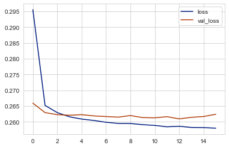

```python
losses[['loss','val_loss']].plot()
```

**Create predictions from the X_test.**

```python
from sklearn.metrics import classification_report,confusion_matrix
```

```python
predictions = (model.predict(X_test) > 0.5).astype("int32")
```

**classification report and confusion matrix**

```python
print(classification_report(y_test,predictions))
```

```
              precision    recall  f1-score   support

           0       1.00      0.43      0.60     15658
           1       0.88      1.00      0.93     63386

    accuracy                           0.89     79044
   macro avg       0.94      0.72      0.77     79044
weighted avg       0.90      0.89      0.87     79044
```

```python
confusion_matrix(y_test,predictions)
```

```
array([[ 6745,  8913],
       [   26, 63360]], dtype=int64)
```

**Deploy model on a random customer**

```python
import random
random.seed(101)
random_ind = random.randint(0,len(df))

new_customer = df.drop('loan_repaid',axis=1).iloc[random_ind]
new_customer
```

```
loan_amnt           25000.00
term                   60.00
int_rate               18.24
installment           638.11
annual_inc          61665.00
                      ...
48052                   0.00
70466                   0.00
86630                   0.00
93700                   0.00
earliest_cr_year     1996.00
Name: 305323, Length: 78, dtype: float64
```

```python
(model.predict(new_customer.values.reshape(1,78)) > 0.5).astype("int32")
```

```
array([[1]])
```

```python
df.iloc[random_ind]['loan_repaid']
```

```
1.0
```